# Introduction to ggplot2 homework

Jerry Balloch

```r
# load in libraries needed
library(tidyverse)
library(CodeClanData)
library(scales)
```

# Question 1.

Load in the libraries you need, and look at the backpack data. Take note of variable names and dimensions.

Variable names: [1] “backpack_weight” “body_weight” “ratio” “back_problems” “major”  
[6] “year” “sex” “status” “units”

Dimensions: [1] 100 9

```r
# read in data and explore
backpack <- backpack

# get variable names
names(backpack)
```

```
## [1] "backpack_weight" "body_weight"     "ratio"           "back_problems"
## [5] "major"           "year"            "sex"             "status"
## [9] "units"
```

```r
# get dimensions
dim(backpack)
```

```
## [1] 100   9
```

# Question 2.

What is the distribution of backpack weights that students are carrying? Choose an appropriate graph to show the distribution.

Backpack weights seem to be more common in the 5 - 15 lb range.

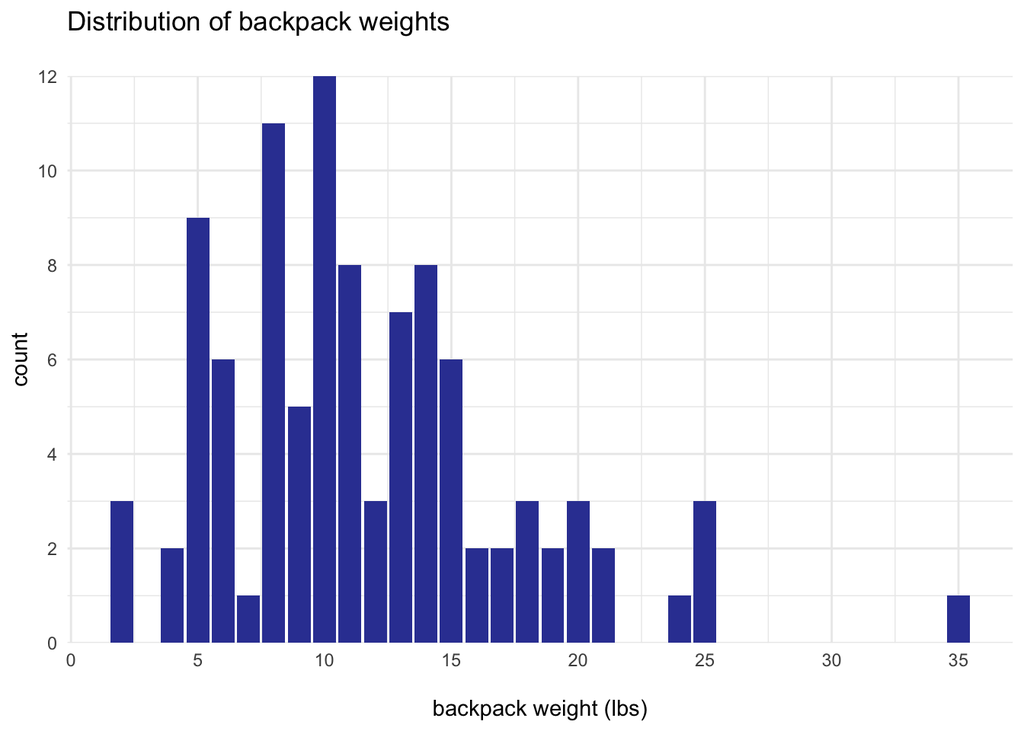

```r
ggplot(backpack) +
  aes(backpack_weight) +
  geom_bar(fill = "#3542a1") +
  labs(x = "\nbackpack weight (lbs)",
       y = "count",
       title = "Distribution of backpack weights\n") +
  scale_x_continuous(breaks = seq(0,40,5)) +
  scale_y_continuous(breaks = seq(0,15,2), expand = c(0,0)) +
  theme_minimal()
```

# Question 3.

Are there differences in backpack weight between sex?

It appears that more backpack weight is carried by females overall.

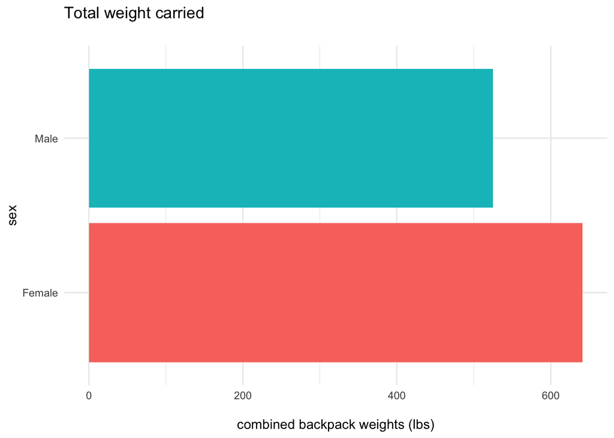

```r
backpack %>%
  ggplot() +
  aes(x = (backpack_weight = mean(backpack_weight)), sex, fill = sex) +
  geom_col() +
  labs(x = "\ncombined backpack weights (lbs)",
       title = "Total weight carried\n") +
  theme_minimal() +
  theme(legend.position = "none")
```

# Question 4.

What is the relationship between body weight and backpack weight?

I can see no clear correlation between backpack weight and body weight. One observation from the chart below is the person carrying the heaviest backpack does not suffer from back problems - light blue dots indicate back problems, dark blue no back problems.

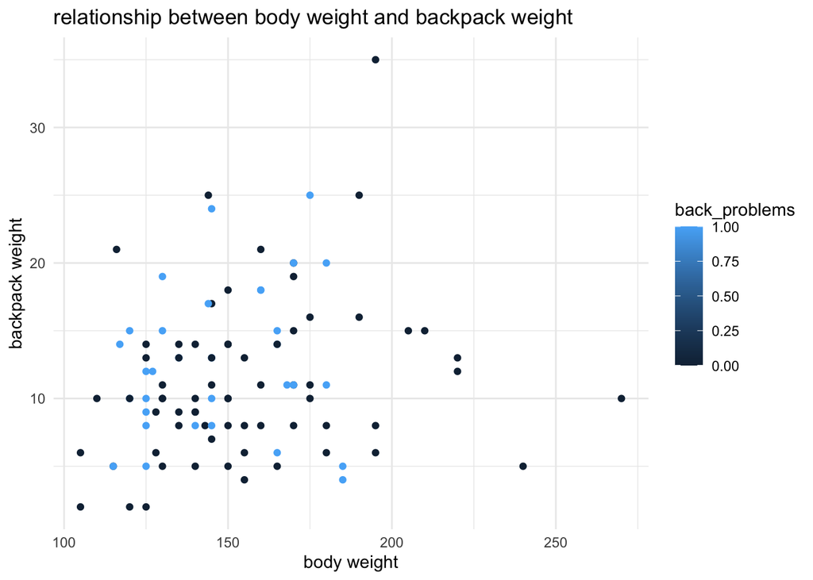

```r
ggplot(backpack) +
  aes(x = body_weight, y = backpack_weight, colour = back_problems) +
  geom_point()+
  labs(x = "body weight",
       y = "backpack weight",
       title = "relationship between body weight and backpack weight") +
  theme_minimal()
```

# Question 5.

Is this relationship different between men and women? Choose an appropriate plot and interpret your findings.

Backpack weight is slightly more concentrated in the 5 - 15 lb range for females, while body weight is generally less than males.

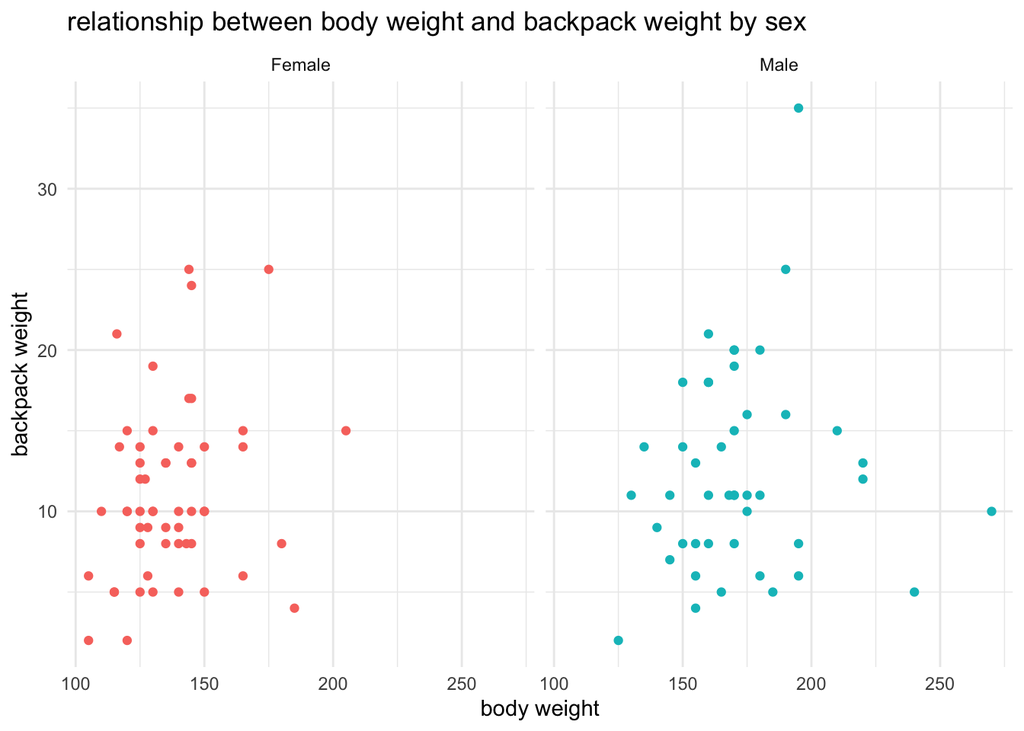

```r
ggplot(backpack) +
  aes(x = body_weight, y = backpack_weight, colour = sex) +
  geom_point()+
  #geom_line(aes(mean(body_weight)), colour="blue", linetype="11", size=0.3) +
  labs(x = "body weight",
       y = "backpack weight",
       title = "relationship between body weight and backpack weight by sex") +
  theme_minimal() +
  facet_wrap(~sex) +
    theme(legend.position = "none")
```

# Question 6.

What proportion of students report back pain?

There are a larger proportion of students not suffering from back problems than those that do.

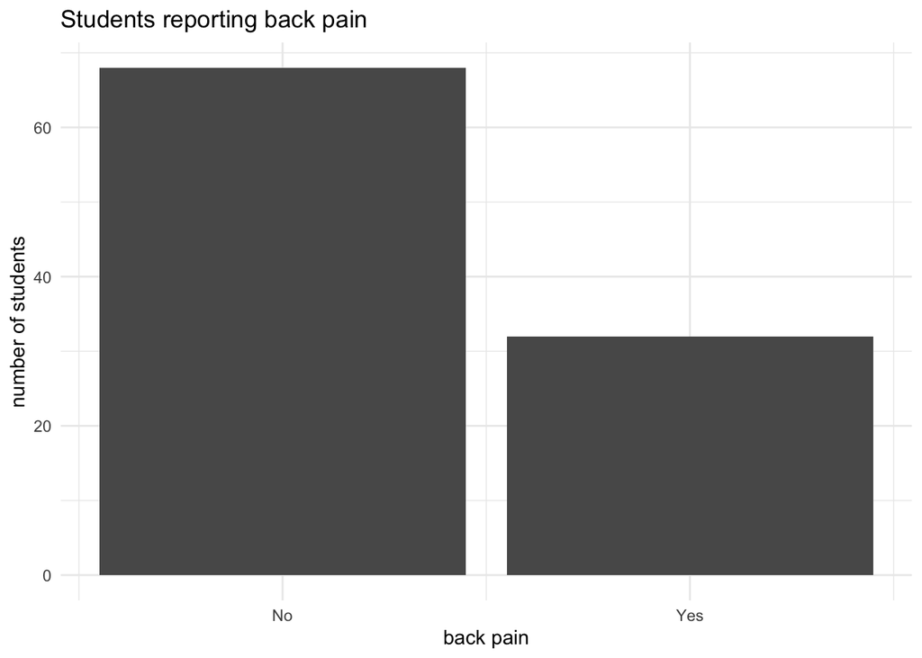

```r
ggplot(backpack) +
  aes(x = back_problems) +
  geom_bar()+
  labs(x = "back pain",
       y = "number of students",
       title = "Students reporting back pain") +
  theme_minimal() +
   scale_x_continuous(breaks = seq(0, 1), labels = c("No", "Yes"))
```

# Question 7.

Is this proportion different between men and women?

It appears that the majority of students that suffer back problems are female - over double that of males.

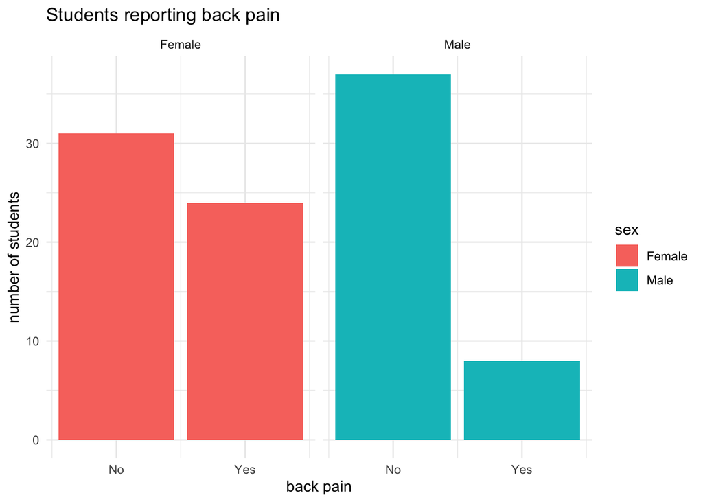

```r
ggplot(backpack) +
  aes(x = back_problems, fill = sex) +
  geom_bar()+
  labs(x = "back pain",
       y = "number of students",
       title = "Students reporting back pain") +
  theme_minimal() +
   scale_x_continuous(breaks = seq(0, 1), labels = c("No", "Yes")) +
  facet_grid(~sex)
```

# Question 8.

Now you’ve investigated your data separately, create plots to describe the relationship between backpack weight, body weight, gender and reported backpain.

Try both backpack_weight and body_weight as well as the ratio.

Hint: faceting would be useful here.